# 1 Práctica 1: Estadísticas descriptivas

# 2 Introducción

El principal obletivo de este estudio es conocer que factores afectan más al desarrollo de trastornos de sueño o no desarrollarlos. Para realizar el estudio se ha descartado Person,ID ya que no es relevante para el estudio, debido a que su funcion es enumerar el total de encuestados. Las variables a analizar como la edad, la profesión, actividad física… Son factoes que afectan a los sujetos estudiados y observaremos su relación o como se afectan entre sí y al diagnostico recivido.

Para realizar nuestro análisis hemos utilizado las siguientes librerías:

# 3 Importación de datos y carga de paquetes

```r
library(tidyverse)
library(flextable)
library(summarytools)
library(knitr)
library(GGally)

datos2 <- read.csv("Sleep_health_and_lifestyle_dataset.csv")
```

# 4 Diccionario de datos

# 5 Análisis exploratorio de datos

## 5.1 Datos univariantes

### 5.1.1 Hombres y mujeres participantes en el estudio

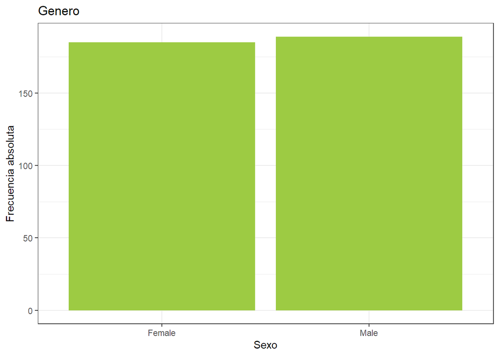

```r
datos2 |>
  ggplot(aes(x = Gender)) +
  geom_bar(fill = "#9dcb43") +
  theme_bw() +
  labs(title = "Genero",
       x = "Sexo",
       y = "Frecuencia absoluta")
```

```r
tabla_frecuencias_genero <- datos2 |>

  count(Gender)|>

  mutate(
    N = cumsum(n),
    f = round(n / nrow(datos2), 4),
    F = round(cumsum(f), 4)
  )

flextable(tabla_frecuencias_genero) |>
   flextable::set_header_labels(
      Freq = "n",
      f = "Frecuencia Relativa",
      N = "Frecuencia Acumulada",
      F = "Frecuencia Relativa Acumulada"
  )
```

| Gender | n | Frecuencia Acumulada | Frecuencia Relativa | Frecuencia Relativa Acumulada |
| --- | --- | --- | --- | --- |
| Female | 185 | 185 | 0.4947 | 0.4947 |
| Male | 189 | 374 | 0.5053 | 1.0000 |

Los datos nos muestra que hay un número aproximado de hombres y mujeres aunque si los resultados se basan en el geneno al haber un leve numero mayor de hombres puede inclinar la balanza a su favor.Gracias a las graficas conocemos un total de 185 mujeres y 189 hombres.

### 5.1.2 Edades

```r
tabla_frecuencias_edad <- datos2 |>

  count(Age)|>

  mutate(
    N = cumsum(n),
    f = round(n / nrow(datos2), 4),
    F = round(cumsum(f), 4)
  )

flextable(tabla_frecuencias_edad) |>
   flextable::set_header_labels(
      Var1 = "Edad",
      Freq = "n",
      f = "Frecuencia Relativa",
      N = "Frecuencia Acumulada",
      F = "Frecuencia Relativa Acumulada"
  )
```

| Age | n | Frecuencia Acumulada | Frecuencia Relativa | Frecuencia Relativa Acumulada |
| --- | --- | --- | --- | --- |
| 27 | 1 | 1 | 0.0027 | 0.0027 |
| 28 | 5 | 6 | 0.0134 | 0.0161 |
| 29 | 13 | 19 | 0.0348 | 0.0509 |
| 30 | 13 | 32 | 0.0348 | 0.0857 |
| 31 | 18 | 50 | 0.0481 | 0.1338 |
| 32 | 17 | 67 | 0.0455 | 0.1793 |
| 33 | 13 | 80 | 0.0348 | 0.2141 |
| 34 | 2 | 82 | 0.0053 | 0.2194 |
| 35 | 12 | 94 | 0.0321 | 0.2515 |
| 36 | 12 | 106 | 0.0321 | 0.2836 |
| 37 | 20 | 126 | 0.0535 | 0.3371 |
| 38 | 20 | 146 | 0.0535 | 0.3906 |
| 39 | 15 | 161 | 0.0401 | 0.4307 |
| 40 | 4 | 165 | 0.0107 | 0.4414 |
| 41 | 12 | 177 | 0.0321 | 0.4735 |
| 42 | 9 | 186 | 0.0241 | 0.4976 |
| 43 | 34 | 220 | 0.0909 | 0.5885 |
| 44 | 30 | 250 | 0.0802 | 0.6687 |
| 45 | 14 | 264 | 0.0374 | 0.7061 |
| 48 | 3 | 267 | 0.0080 | 0.7141 |
| 49 | 11 | 278 | 0.0294 | 0.7435 |
| 50 | 20 | 298 | 0.0535 | 0.7970 |
| 51 | 8 | 306 | 0.0214 | 0.8184 |
| 52 | 9 | 315 | 0.0241 | 0.8425 |
| 53 | 17 | 332 | 0.0455 | 0.8880 |
| 54 | 7 | 339 | 0.0187 | 0.9067 |
| 55 | 2 | 341 | 0.0053 | 0.9120 |
| 56 | 2 | 343 | 0.0053 | 0.9173 |
| 57 | 9 | 352 | 0.0241 | 0.9414 |
| 58 | 6 | 358 | 0.0160 | 0.9574 |
| 59 | 16 | 374 | 0.0428 | 1.0002 |

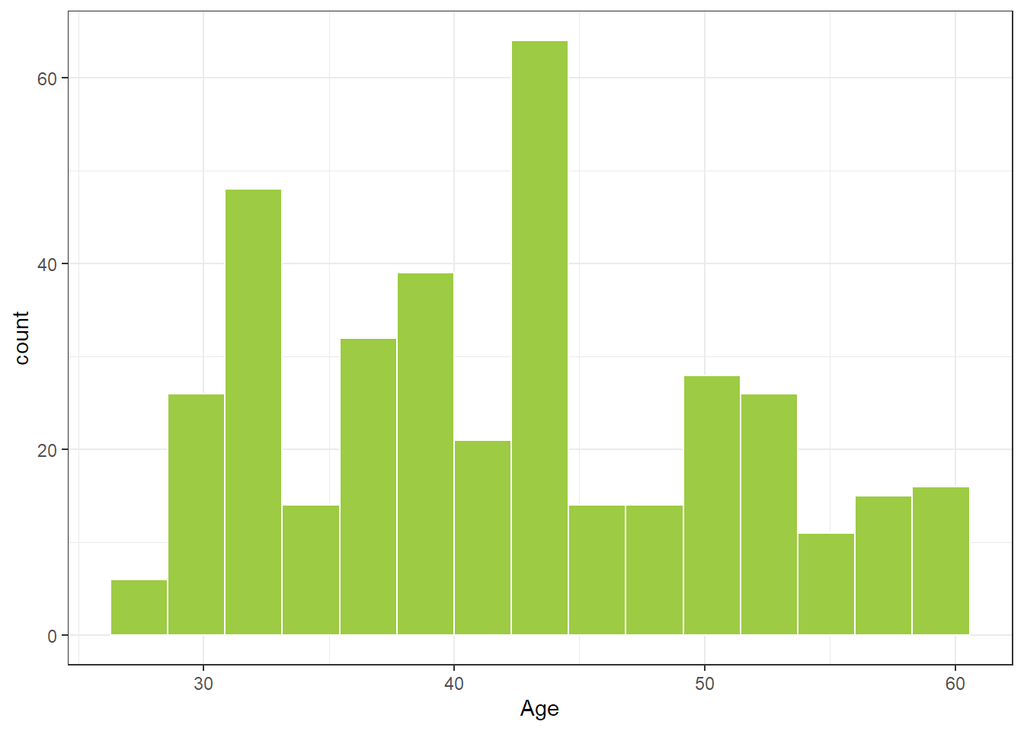

```r
datos2 |> ggplot(aes(x=Age)) +

  geom_histogram(
    fill = "#9dcb43",
    bins = 15,
    col = "white"
  ) +

  theme_bw()
```

```r
datos2 |> descr(Age)
```

```
## Descriptive Statistics
## datos2$Age
## N: 374
##
##                        Age
## ----------------- --------
##              Mean    42.18
##           Std.Dev     8.67
##               Min    27.00
##                Q1    35.00
##            Median    43.00
##                Q3    50.00
##               Max    59.00
##               MAD    10.38
##               IQR    14.75
##                CV     0.21
##          Skewness     0.26
##       SE.Skewness     0.13
##          Kurtosis    -0.92
##           N.Valid   374.00
##         Pct.Valid   100.00
```

```r
summary(datos2$Age)
```

```
##    Min. 1st Qu.  Median    Mean 3rd Qu.    Max.
##   27.00   35.25   43.00   42.18   50.00   59.00
```

El estudio se ha centrado en sujetos de edad adulta entre los 27 y los 59 años, con una media de edad en el estudio de 42.18. Y se puede observar que la el mayor número de encuestados tiene una edad cerca a los 40.

### 5.1.3 Profesiones

```r
tabla_frecuencias_profesion <- datos2 |>

  count(Occupation)|>

  mutate(
    N = cumsum(n),
    f = round(n / nrow(datos2), 4),
    F = round(cumsum(f), 4)
  )

flextable(tabla_frecuencias_profesion) |>
   flextable::set_header_labels(
      Freq = "n",
      f = "Frecuencia Relativa",
      N = "Frecuencia Acumulada",
      F = "Frecuencia Relativa Acumulada"
  )
```

| Occupation | n | Frecuencia Acumulada | Frecuencia Relativa | Frecuencia Relativa Acumulada |
| --- | --- | --- | --- | --- |
| Accountant | 37 | 37 | 0.0989 | 0.0989 |
| Doctor | 71 | 108 | 0.1898 | 0.2887 |
| Engineer | 63 | 171 | 0.1684 | 0.4571 |
| Lawyer | 47 | 218 | 0.1257 | 0.5828 |
| Manager | 1 | 219 | 0.0027 | 0.5855 |
| Nurse | 73 | 292 | 0.1952 | 0.7807 |
| Sales Representative | 2 | 294 | 0.0053 | 0.7860 |
| Salesperson | 32 | 326 | 0.0856 | 0.8716 |
| Scientist | 4 | 330 | 0.0107 | 0.8823 |
| Software Engineer | 4 | 334 | 0.0107 | 0.8930 |
| Teacher | 40 | 374 | 0.1070 | 1.0000 |

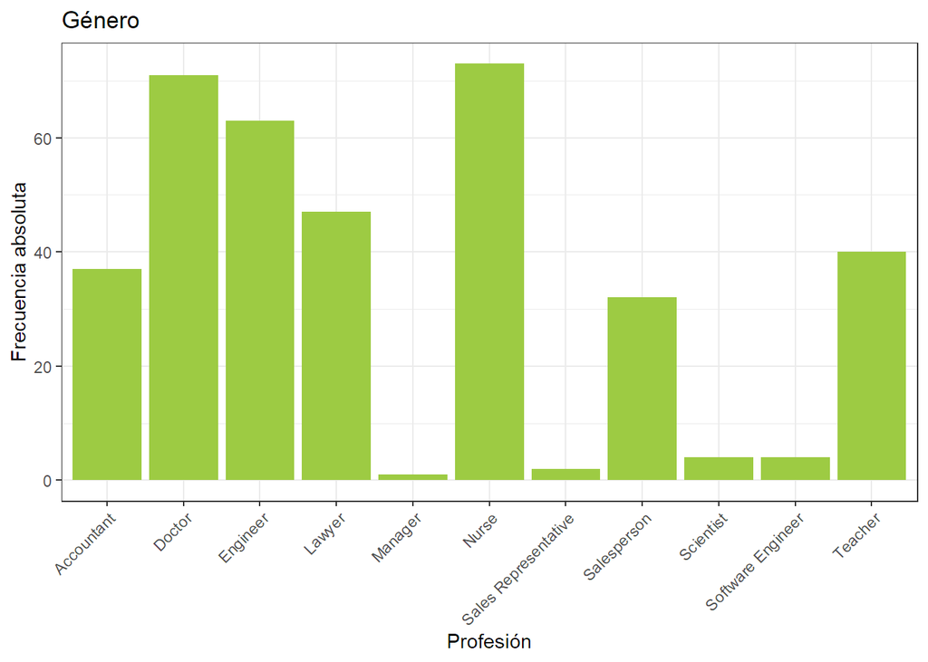

```r
datos2 |>
  ggplot(aes(x = Occupation)) +
  geom_bar(fill = "#9dcb43") +
  theme_bw() +
  labs(title = "Género",
       x = "Profesión",
       y = "Frecuencia absoluta")+
  theme(axis.text.x = element_text(angle = 45, hjust = 1))
```

Los sujetos mas encuestados para el estudio han sido doctores y enfermeras con un total de 73 enfermeras y 71 médicos. Duración de sueño

### 5.1.4 Duración de sueño

```r
datos2['Duración_sueño'] <- cut(datos2$Sleep.Duration, breaks = c(5.5, 6, 6.5, 7, 7.5, 8, 8.5),
                  labels = c('5,5-6', '6-6,5', '6,5-7', '7-7,5', '7,5-8', '8-8,5'))



tabla_frecuencias_duracion_sueño <- datos2 |>

  count(Duración_sueño)|>

  mutate(
    N = cumsum(n),
    f = round(n / nrow(datos2), 4),
    F = round(cumsum(f), 4)
  )

flextable(tabla_frecuencias_duracion_sueño) |>
   flextable::set_header_labels(
      Var1 = "Duración",
      Freq = "n",
      f = "Frecuencia Relativa",
      N = "Frecuencia Acumulada",
      F = "Frecuencia Relativa Acumulada"
  )
```

| Duración_sueño | n | Frecuencia Acumulada | Frecuencia Relativa | Frecuencia Relativa Acumulada |
| --- | --- | --- | --- | --- |
| 5,5-6 | 37 | 37 | 0.0989 | 0.0989 |
| 6-6,5 | 85 | 122 | 0.2273 | 0.3262 |
| 6,5-7 | 33 | 155 | 0.0882 | 0.4144 |
| 7-7,5 | 79 | 234 | 0.2112 | 0.6256 |
| 7,5-8 | 82 | 316 | 0.2193 | 0.8449 |
| 8-8,5 | 58 | 374 | 0.1551 | 1.0000 |

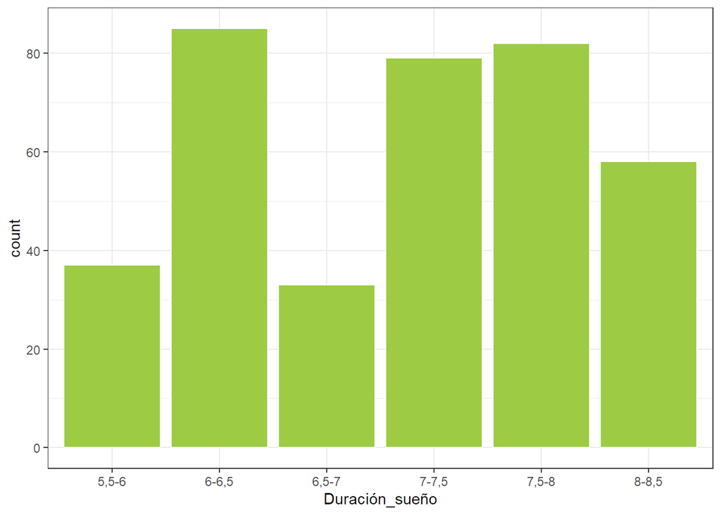

```r
datos2 |> ggplot(aes(x = Duración_sueño)) +
    geom_bar(fill = "#9dcb43", col = "white") +
    theme_bw()
```

```r
datos2 |> descr(Sleep.Duration)
```

```
## Descriptive Statistics
## datos2$Sleep.Duration
## N: 374
##
##                     Sleep.Duration
## ----------------- ----------------
##              Mean             7.13
##           Std.Dev             0.80
##               Min             5.80
##                Q1             6.40
##            Median             7.20
##                Q3             7.80
##               Max             8.50
##               MAD             1.04
##               IQR             1.40
##                CV             0.11
##          Skewness             0.04
##       SE.Skewness             0.13
##          Kurtosis            -1.29
##           N.Valid           374.00
##         Pct.Valid           100.00
```

```r
summary(datos2$Sleep.Duration)
```

```
##    Min. 1st Qu.  Median    Mean 3rd Qu.    Max.
##   5.800   6.400   7.200   7.132   7.800   8.500
```

Teniendo en cuenta que el sueño mínimo recomendado en adultos son 7 horas, podemos ver que aproximadamente un 40% de los individuos de la muestra no duermen suficientes horas.

### 5.1.5 Calidad de sueño

```r
tabla_frecuencias_calidad_sueño <- datos2 |>

  count(Quality.of.Sleep)|>

  mutate(
    N = cumsum(n),
    f = round(n / nrow(datos2), 4),
    F = round(cumsum(f), 4)
  )

flextable(tabla_frecuencias_duracion_sueño) |>
   flextable::set_header_labels(
      Var1 = "Calidad",
      Freq = "n",
      f = "Frecuencia Relativa",
      N = "Frecuencia Acumulada",
      F = "Frecuencia Relativa Acumulada"
  )
```

[output not shown]

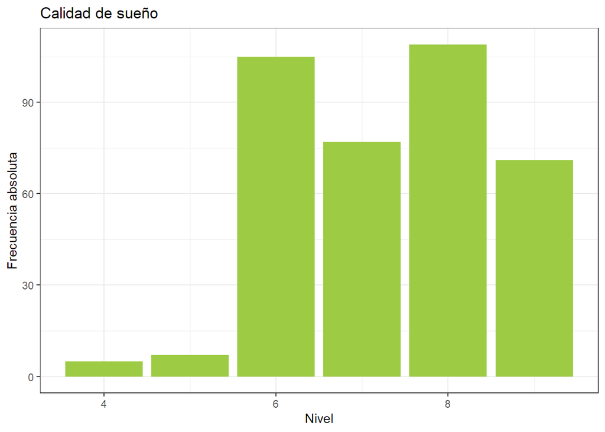

```r
datos2 |>
  ggplot(aes(x = Quality.of.Sleep)) +
  geom_bar(fill = "#9dcb43") +
  theme_bw() +
  labs(title = "Calidad de sueño",
       x = "Nivel",
       y = "Frecuencia absoluta")
```

```r
datos2 |> descr(Quality.of.Sleep)
```

```
## Descriptive Statistics
## datos2$Quality.of.Sleep
## N: 374
##
##                     Quality.of.Sleep
## ----------------- ------------------
##              Mean               7.31
##           Std.Dev               1.20
##               Min               4.00
##                Q1               6.00
##            Median               7.00
##                Q3               8.00
##               Max               9.00
##               MAD               1.48
##               IQR               2.00
##                CV               0.16
##          Skewness              -0.21
##       SE.Skewness               0.13
##          Kurtosis              -0.77
##           N.Valid             374.00
##         Pct.Valid             100.00
```

```r
summary(datos2$Quality.of.Sleep)
```

```
##    Min. 1st Qu.  Median    Mean 3rd Qu.    Max.
##   4.000   6.000   7.000   7.313   8.000   9.000
```

### 5.1.6 Nivel de actividad física

```r
tabla_frecuencias_actividad_física <- datos2 |>

  count(Physical.Activity.Level)|>

  mutate(
    N = cumsum(n),
    f = round(n / nrow(datos2), 4),
    F = round(cumsum(f), 4)
  )

flextable(tabla_frecuencias_actividad_física) |>
   flextable::set_header_labels(
      Var1 = "Actividad",
      Freq = "n",
      f = "Frecuencia Relativa",
      N = "Frecuencia Acumulada",
      F = "Frecuencia Relativa Acumulada"
  )
```

| Physical.Activity.Level | n | Frecuencia Acumulada | Frecuencia Relativa | Frecuencia Relativa Acumulada |
| --- | --- | --- | --- | --- |
| 30 | 68 | 68 | 0.1818 | 0.1818 |
| 32 | 2 | 70 | 0.0053 | 0.1871 |
| 35 | 4 | 74 | 0.0107 | 0.1978 |
| 40 | 6 | 80 | 0.0160 | 0.2138 |
| 42 | 2 | 82 | 0.0053 | 0.2191 |
| 45 | 68 | 150 | 0.1818 | 0.4009 |
| 47 | 1 | 151 | 0.0027 | 0.4036 |
| 50 | 4 | 155 | 0.0107 | 0.4143 |
| 55 | 6 | 161 | 0.0160 | 0.4303 |
| 60 | 70 | 231 | 0.1872 | 0.6175 |
| 65 | 2 | 233 | 0.0053 | 0.6228 |
| 70 | 3 | 236 | 0.0080 | 0.6308 |
| 75 | 67 | 303 | 0.1791 | 0.8099 |
| 80 | 2 | 305 | 0.0053 | 0.8152 |
| 85 | 2 | 307 | 0.0053 | 0.8205 |
| 90 | 67 | 374 | 0.1791 | 0.9996 |

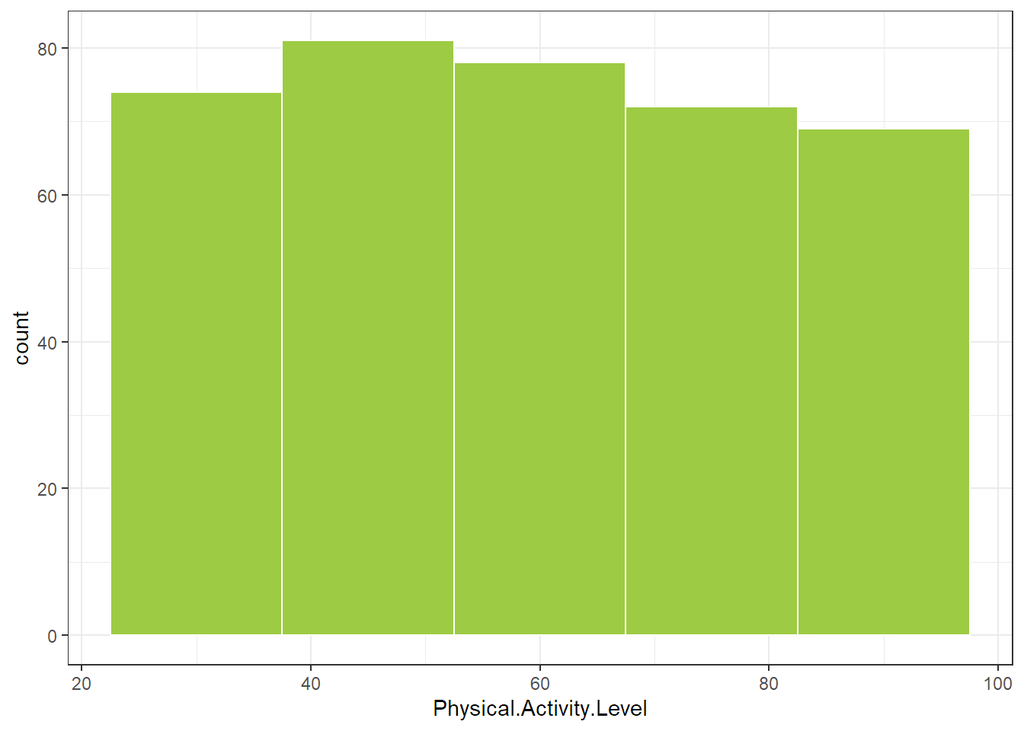

```r
datos2 |> ggplot(aes(Physical.Activity.Level)) +

  geom_histogram(
    fill = "#9dcb43",
    bins = 5,
    col = "white"
  ) +


  theme_bw()
```

```r
datos2 |> descr(Physical.Activity.Level)
```

```
## Descriptive Statistics
## datos2$Physical.Activity.Level
## N: 374
##
##                     Physical.Activity.Level
## ----------------- -------------------------
##              Mean                     59.17
##           Std.Dev                     20.83
##               Min                     30.00
##                Q1                     45.00
##            Median                     60.00
##                Q3                     75.00
##               Max                     90.00
##               MAD                     22.24
##               IQR                     30.00
##                CV                      0.35
##          Skewness                      0.07
##       SE.Skewness                      0.13
##          Kurtosis                     -1.27
##           N.Valid                    374.00
##         Pct.Valid                    100.00
```

```r
summary(datos2$Physical.Activity.Level)
```

```
##    Min. 1st Qu.  Median    Mean 3rd Qu.    Max.
##   30.00   45.00   60.00   59.17   75.00   90.00
```

El nivel de actividad física se reparte de manera más o menos equitativa a lo largo de la muestra, lo que significa que hay una gran variedad de resultados y que no hay una clara mayoría.

### 5.1.7 Nivel de estrés de los participantes

```r
tabla_frecuencias_estres <- datos2 |>

  count(Stress.Level)|>

  mutate(
    N = cumsum(n),
    f = round(n / nrow(datos2), 4),
    F = round(cumsum(f), 4)
  )

flextable(tabla_frecuencias_estres) |>
   flextable::set_header_labels(
      Var1 = "Estrés",
      Freq = "n",
      f = "Frecuencia Relativa",
      N = "Frecuencia Acumulada",
      F = "Frecuencia Relativa Acumulada"
  )
```

| Stress.Level | n | Frecuencia Acumulada | Frecuencia Relativa | Frecuencia Relativa Acumulada |
| --- | --- | --- | --- | --- |
| 3 | 71 | 71 | 0.1898 | 0.1898 |
| 4 | 70 | 141 | 0.1872 | 0.3770 |
| 5 | 67 | 208 | 0.1791 | 0.5561 |
| 6 | 46 | 254 | 0.1230 | 0.6791 |
| 7 | 50 | 304 | 0.1337 | 0.8128 |
| 8 | 70 | 374 | 0.1872 | 1.0000 |

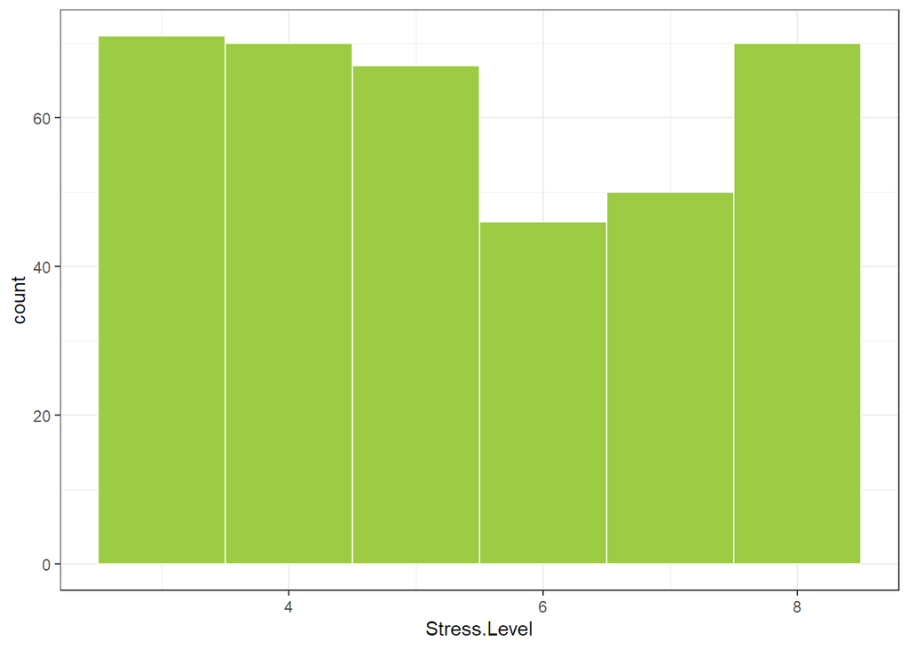

```r
datos2 |> ggplot(aes(x=Stress.Level)) +

  geom_histogram(
    fill = "#9dcb43",
    bins = 6,
    col = "white"
  ) +

  theme_bw()
```

```r
datos2 |> descr(Stress.Level)
```

```
## Descriptive Statistics
## datos2$Stress.Level
## N: 374
##
##                     Stress.Level
## ----------------- --------------
##              Mean           5.39
##           Std.Dev           1.77
##               Min           3.00
##                Q1           4.00
##            Median           5.00
##                Q3           7.00
##               Max           8.00
##               MAD           2.97
##               IQR           3.00
##                CV           0.33
##          Skewness           0.15
##       SE.Skewness           0.13
##          Kurtosis          -1.33
##           N.Valid         374.00
##         Pct.Valid         100.00
```

```r
summary(datos2$Stress.Level)
```

```
##    Min. 1st Qu.  Median    Mean 3rd Qu.    Max.
##   3.000   4.000   5.000   5.385   7.000   8.000
```

Como podemos ver, los participantes del estudio tenían sobre todo niveles de estres por encima del 2, pero va disminuyendo conforme aumenta hasta el “6”. A partir de ahí, se aprecia un ligero crecimiento en el “7” y uno mayor en el “8”. De ese número en adelante no hay participantes.

Teniendo en cuenta este analisis podemos observar que no hay participantes en los extremos del nivel de estrés, estando así medianamente equilibrado pero con suficiente variación como para comprobar si el alto estrés afecta al sueño.

### 5.1.8 Categoría del IMC de los participantes

```r
tabla_frecuencias_IMC <- datos2 |>

  count(BMI.Category)|>

  mutate(
    N = cumsum(n),
    f = round(n / nrow(datos2), 4),
    F = round(cumsum(f), 4)
  )

flextable(tabla_frecuencias_IMC) |>
   flextable::set_header_labels(
      Freq = "n",
      f = "Frecuencia Relativa",
      N = "Frecuencia Acumulada",
      F = "Frecuencia Relativa Acumulada"
  )
```

| BMI.Category | n | Frecuencia Acumulada | Frecuencia Relativa | Frecuencia Relativa Acumulada |
| --- | --- | --- | --- | --- |
| Normal | 195 | 195 | 0.5214 | 0.5214 |
| Normal Weight | 21 | 216 | 0.0561 | 0.5775 |
| Obese | 10 | 226 | 0.0267 | 0.6042 |
| Overweight | 148 | 374 | 0.3957 | 0.9999 |

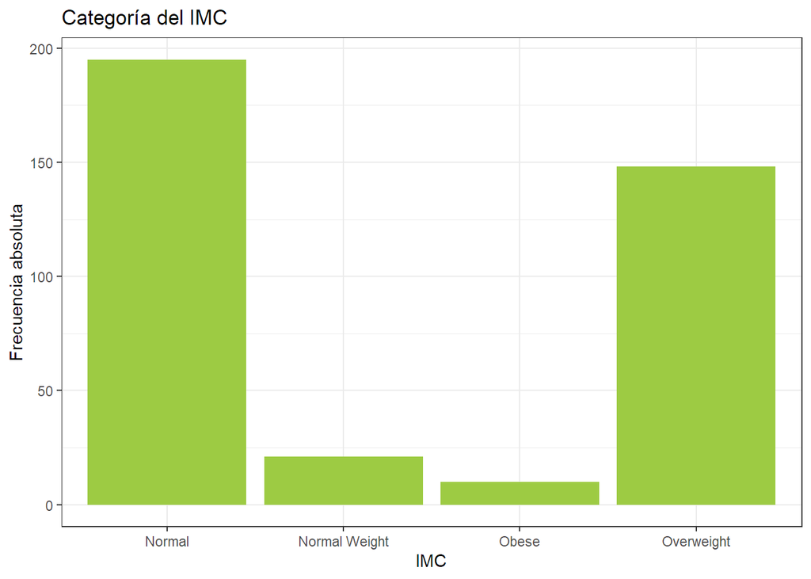

```r
datos2 |>
  ggplot(aes(x = BMI.Category)) +
  geom_bar(fill = "#9dcb43") +
  theme_bw() +
  labs(title = "Categoría del IMC",
       x = "IMC",
       y = "Frecuencia absoluta")
```

Como se puede observar, los participantes están, en su mayoría, en un peso IMC normal, sin embargo también podemos encontrar un gran número de estos con sobrepeso, por lo que en el estudio se podrá comprobar claramente si el sobrepeso afecta al sueño.

### 5.1.9 Presión sanguínea de los participantes

```r
tabla_frecuencias_presion <- datos2 |>

  count(Blood.Pressure)|>

  mutate(
    N = cumsum(n),
    f = round(n / nrow(datos2), 4),
    F = round(cumsum(f), 4)
  )

flextable(tabla_frecuencias_presion) |>
   flextable::set_header_labels(
      Freq = "n",
      f = "Frecuencia Relativa",
      N = "Frecuencia Acumulada",
      F = "Frecuencia Relativa Acumulada"
  )
```

| Blood.Pressure | n | Frecuencia Acumulada | Frecuencia Relativa | Frecuencia Relativa Acumulada |
| --- | --- | --- | --- | --- |
| 115/75 | 32 | 32 | 0.0856 | 0.0856 |
| 115/78 | 2 | 34 | 0.0053 | 0.0909 |
| 117/76 | 2 | 36 | 0.0053 | 0.0962 |
| 118/75 | 2 | 38 | 0.0053 | 0.1015 |
| 118/76 | 1 | 39 | 0.0027 | 0.1042 |
| 119/77 | 2 | 41 | 0.0053 | 0.1095 |
| 120/80 | 45 | 86 | 0.1203 | 0.2298 |
| 121/79 | 1 | 87 | 0.0027 | 0.2325 |
| 122/80 | 1 | 88 | 0.0027 | 0.2352 |
| 125/80 | 65 | 153 | 0.1738 | 0.4090 |
| 125/82 | 4 | 157 | 0.0107 | 0.4197 |
| 126/83 | 2 | 159 | 0.0053 | 0.4250 |
| 128/84 | 2 | 161 | 0.0053 | 0.4303 |
| 128/85 | 3 | 164 | 0.0080 | 0.4383 |
| 129/84 | 2 | 166 | 0.0053 | 0.4436 |
| 130/85 | 99 | 265 | 0.2647 | 0.7083 |
| 130/86 | 2 | 267 | 0.0053 | 0.7136 |
| 131/86 | 2 | 269 | 0.0053 | 0.7189 |
| 132/87 | 3 | 272 | 0.0080 | 0.7269 |
| 135/88 | 2 | 274 | 0.0053 | 0.7322 |
| 135/90 | 27 | 301 | 0.0722 | 0.8044 |
| 139/91 | 2 | 303 | 0.0053 | 0.8097 |
| 140/90 | 4 | 307 | 0.0107 | 0.8204 |
| 140/95 | 65 | 372 | 0.1738 | 0.9942 |
| 142/92 | 2 | 374 | 0.0053 | 0.9995 |

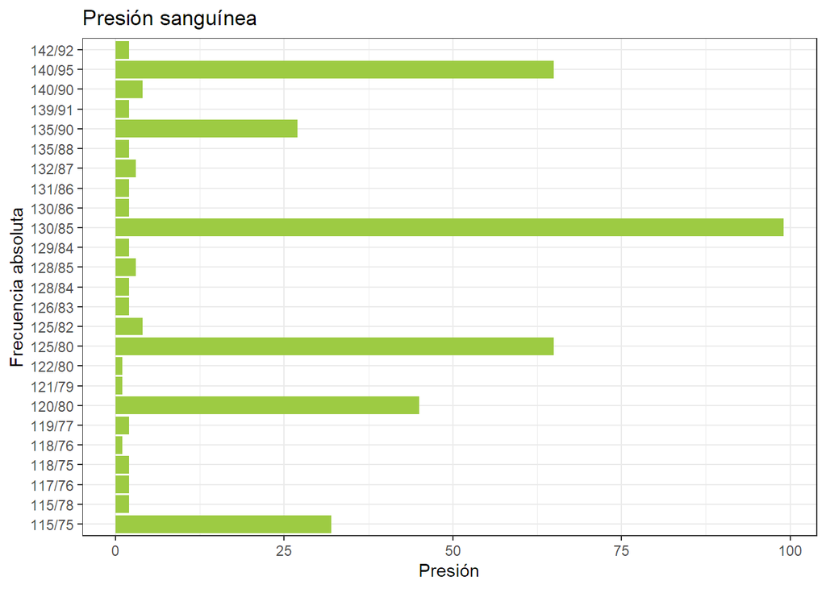

```r
datos2 |>
  ggplot(aes(y = Blood.Pressure)) +
  geom_bar(fill = "#9dcb43") +
  theme_bw() +
  labs(title = "Presión sanguínea",
       x = "Presión",
       y = "Frecuencia absoluta")
```

## 5.2 Datos bivariantes

### 5.2.1 Covarianza y correlacion

Covarianza

```r
datos2 |> select(where(is.numeric), -Person.ID) |>
  drop_na() |>
  cov() |>
  round(2)
```

```
##                            Age Sleep.Duration Quality.of.Sleep
## Age                      75.22           2.38             4.92
## Sleep.Duration            2.38           0.63             0.84
## Quality.of.Sleep          4.92           0.84             1.43
## Physical.Activity.Level  32.34           3.52             4.81
## Stress.Level             -6.50          -1.15            -1.91
## Heart.Rate               -8.09          -1.70            -3.27
## Daily.Steps             813.51         -50.89            32.52
##                         Physical.Activity.Level Stress.Level Heart.Rate
## Age                                       32.34        -6.50      -8.09
## Sleep.Duration                             3.52        -1.15      -1.70
## Quality.of.Sleep                           4.81        -1.91      -3.27
## Physical.Activity.Level                  433.92        -1.26      11.80
## Stress.Level                              -1.26         3.15       4.92
## Heart.Rate                                11.80         4.92      17.10
## Daily.Steps                            26042.69       536.39    -202.80
##                         Daily.Steps
## Age                          813.51
## Sleep.Duration               -50.89
## Quality.of.Sleep              32.52
## Physical.Activity.Level    26042.69
## Stress.Level                 536.39
## Heart.Rate                  -202.80
## Daily.Steps              2617651.14
```

Correlación

```r
datos2 |> select(where(is.numeric), -Person.ID) |>
  drop_na() |>
  cor() |>
  round(2)
```

```
##                           Age Sleep.Duration Quality.of.Sleep
## Age                      1.00           0.34             0.47
## Sleep.Duration           0.34           1.00             0.88
## Quality.of.Sleep         0.47           0.88             1.00
## Physical.Activity.Level  0.18           0.21             0.19
## Stress.Level            -0.42          -0.81            -0.90
## Heart.Rate              -0.23          -0.52            -0.66
## Daily.Steps              0.06          -0.04             0.02
##                         Physical.Activity.Level Stress.Level Heart.Rate
## Age                                        0.18        -0.42      -0.23
## Sleep.Duration                             0.21        -0.81      -0.52
## Quality.of.Sleep                           0.19        -0.90      -0.66
## Physical.Activity.Level                    1.00        -0.03       0.14
## Stress.Level                              -0.03         1.00       0.67
## Heart.Rate                                 0.14         0.67       1.00
## Daily.Steps                                0.77         0.19      -0.03
##                         Daily.Steps
## Age                            0.06
## Sleep.Duration                -0.04
## Quality.of.Sleep               0.02
## Physical.Activity.Level        0.77
## Stress.Level                   0.19
## Heart.Rate                    -0.03
## Daily.Steps                    1.00
```

### 5.2.2 Edad con duración del sueño

```r
edad_horas_de_sueño <- datos2 |>
  mutate(rango_edad = cut(Age, breaks = seq(floor(min(Age)), ceiling(max(Age)), by = 4), include.lowest = TRUE),
         rango_horas_de_sueño=cut(Sleep.Duration,breaks=3)) |>
  count(rango_edad,
        rango_horas_de_sueño)

kable(edad_horas_de_sueño)
```

| rango_edad | rango_horas_de_sueño | n |
| --- | --- | --- |
| [27,31] | (5.8,6.7] | 20 |
| [27,31] | (6.7,7.6] | 4 |
| [27,31] | (7.6,8.5] | 26 |
| (31,35] | (5.8,6.7] | 28 |
| (31,35] | (6.7,7.6] | 14 |
| (31,35] | (7.6,8.5] | 2 |
| (35,39] | (5.8,6.7] | 4 |
| (35,39] | (6.7,7.6] | 59 |
| (35,39] | (7.6,8.5] | 4 |
| (39,43] | (5.8,6.7] | 17 |
| (39,43] | (6.7,7.6] | 13 |
| (39,43] | (7.6,8.5] | 29 |
| (43,47] | (5.8,6.7] | 40 |
| (43,47] | (6.7,7.6] | 4 |
| (47,51] | (5.8,6.7] | 32 |
| (47,51] | (6.7,7.6] | 3 |
| (47,51] | (7.6,8.5] | 7 |
| (51,55] | (5.8,6.7] | 6 |
| (51,55] | (7.6,8.5] | 29 |
| (55,59] | (7.6,8.5] | 33 |

Covarianza

```r
cov(datos2$Age, datos2$Sleep.Duration)
```

```
## [1] 2.378783
```

Al resueltar una covarianza positiva presentan una relacion lineal positiva, creciendo conjuntamente.

Corelación

```r
cor(datos2$Age, datos2$Sleep.Duration)
```

```
## [1] 0.3447094
```

Al ser valor proximo a 0 no hay una relacion lineal fuerte entre ellas por lo que no se modifican notablemente los datos.

Gráfica de dispersión

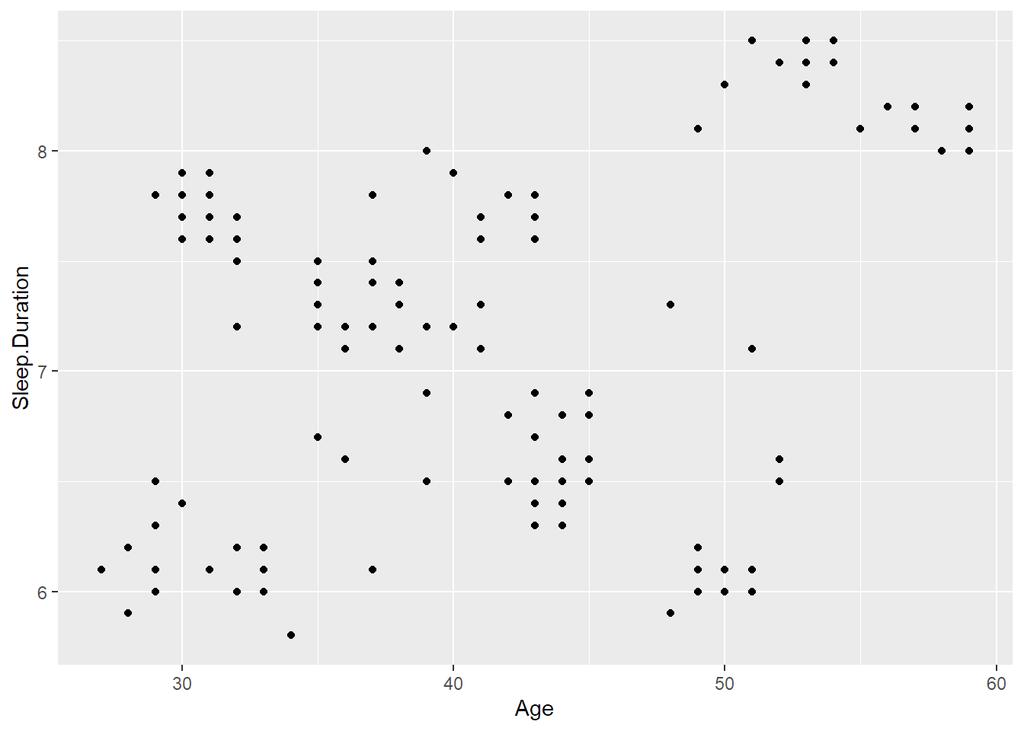

```r
datos2 |>
  ggplot(aes(x = Age, y = Sleep.Duration)) +
  geom_point()
```

El gráfico de dispersion muestra la edad (eje x) frente a la duracion del sueño(eje Y). La dispersion muestra un leve crecimiento segun avanza la edad de los sujetos pero la mayoria de varores se centran entre las 6 y 8 horas. Algunos valores que superan las 8 horas son los sujetos que principalmente han superado los 50 años. Y los que no sus horas de sueño se encuentran por denajo de los 35 años y algun usuario de edad superior.

Regresión lineal:

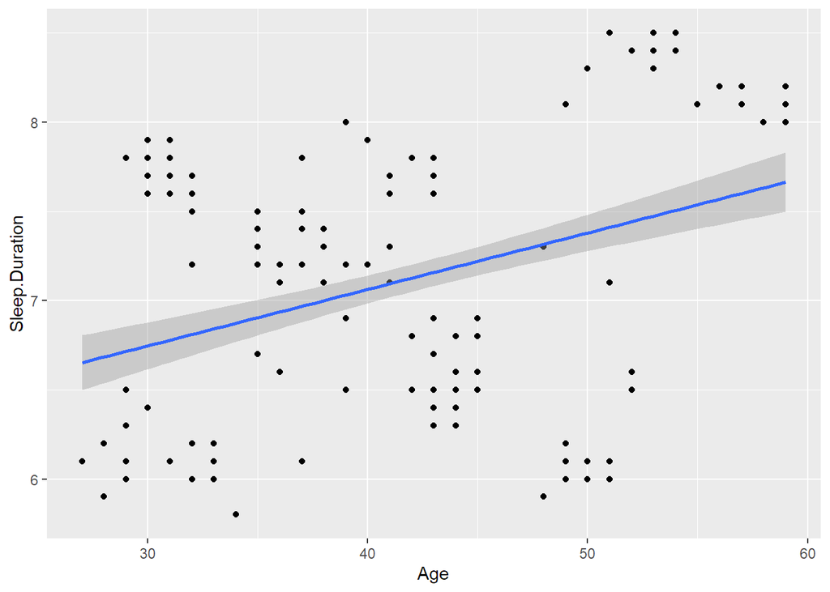

```r
datos2 |>
  ggplot(aes(x = Age, y = Sleep.Duration)) +
  geom_point() +
  geom_smooth(method = lm)
```

```r
edad_duracio_sueno <- lm(Age ~ Sleep.Duration, data = datos2)

summary(edad_duracio_sueno)
```

```
##
## Call:
## lm(formula = Age ~ Sleep.Duration, data = datos2)
##
## Residuals:
##     Min      1Q  Median      3Q     Max
## -15.694  -5.931  -1.694   5.676  13.554
##
## Coefficients:
##                Estimate Std. Error t value Pr(>|t|)
## (Intercept)     15.3854     3.8072   4.041 6.47e-05 ***
## Sleep.Duration   3.7575     0.5305   7.083 7.12e-12 ***
## ---
## Signif. codes:  0 '***' 0.001 '**' 0.01 '*' 0.05 '.' 0.1 ' ' 1
##
## Residual standard error: 8.152 on 372 degrees of freedom
## Multiple R-squared:  0.1188, Adjusted R-squared:  0.1165
## F-statistic: 50.16 on 1 and 372 DF,  p-value: 7.117e-12
```

### 5.2.3 Trastornos con la edad

Tabla comparativa

```r
table(datos2$Age, datos2$Sleep.Disorder)
```

```
##
##      Insomnia None Sleep Apnea
##   27        0    1           0
##   28        1    2           2
##   29        2    9           2
##   30        1   11           1
##   31        0   17           1
##   32        0   17           0
##   33        1   12           0
##   34        0    0           2
##   35        0   11           1
##   36        2    8           2
##   37        0   20           0
##   38        0   18           2
##   39        2   13           0
```

[output cut: 18 more lines]

Gráfico de cajas:

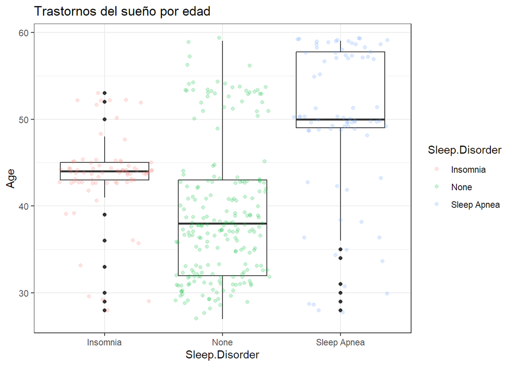

```r
datos2 |>
  ggplot(aes(x = Sleep.Disorder, y = Age)) +
  geom_boxplot() +
  geom_jitter(aes(col = Sleep.Disorder), alpha = 0.2) +
  theme_bw() +
  labs(title = "Trastornos del sueño por edad")
```

Grácias al grafico principalmente los sujetos no presentan algun tipo del trastorno del sueño en torno a los 30 y 40 años. Por otro lado el principal trastorno que se presenta principalmente en torno los 50 y 60 años en la Apnea del sueño y detras de este se encunetra el imsopnio que se presenta en un menor número de sujetos totales entre 40 y 45 años.

### 5.2.4 Profesion con estres

Tabla comparativa

```r
table(datos2$Stress.Level, datos2$Occupation)
```

```
##
##     Accountant Doctor Engineer Lawyer Manager Nurse Sales Representative
##   3          2      4       34      0       0    31                    0
##   4         26      0        9      0       0     4                    0
##   5          0      2       16     44       1     0                    0
##   6          3     32        1      3       0     2                    0
##   7          6      0        3      0       0     4                    0
##   8          0     33        0      0       0    32                    2
##
##     Salesperson Scientist Software Engineer Teacher
##   3           0         0                 0       0
##   4           0         0                 0      31
##   5           0         0                 2       2
##   6           0         2                 1       2
##   7          32         0                 0       5
##   8           0         2                 1       0
```

Gráfico de cajas:

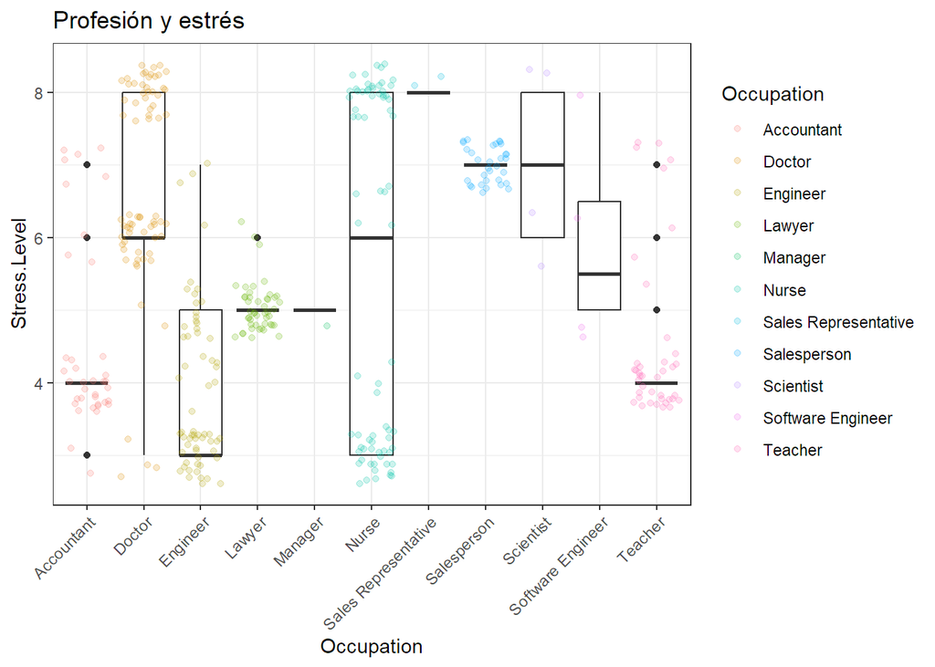

```r
datos2 |>
  ggplot(aes(x = Occupation, y = Stress.Level)) +
  geom_boxplot() +
  geom_jitter(aes(col = Occupation), alpha = 0.2) +
  theme_bw() +
   theme(axis.text.x = element_text(angle = 45, hjust = 1))+
  labs(title = "Profesión y estrés")
```

### 5.2.5 Profesión BMI

Tabla comparativa

```r
table(datos2$Occupation, datos2$BMI.Category)
```

```
##
##                        Normal Normal Weight Obese Overweight
##   Accountant               26             5     0          6
##   Doctor                   65             2     4          0
##   Engineer                 56             4     0          3
##   Lawyer                   42             1     2          2
##   Manager                   0             0     0          1
##   Nurse                     0             7     0         66
##   Sales Representative      0             0     2          0
##   Salesperson               0             0     0         32
##   Scientist                 0             0     0          4
##   Software Engineer         0             2     1          1
##   Teacher                   6             0     1         33
```

Gráfico de barras

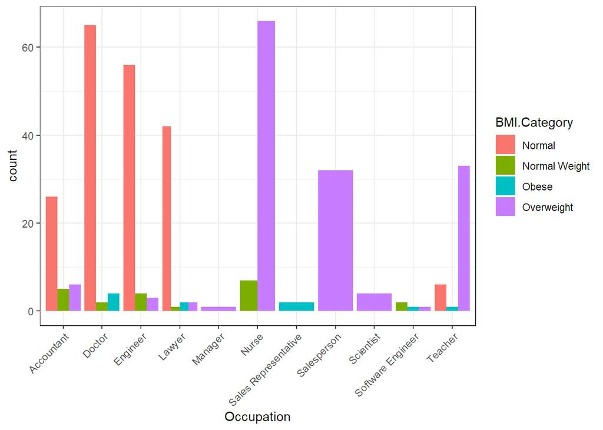

```r
datos2 |>
  ggplot(aes(x = Occupation, fill = BMI.Category)) +
  geom_bar(position = position_dodge()) +
  theme_bw() +
  theme(axis.text.x = element_text(angle = 45, hjust = 1))
```

Podemos apreciar cómo la posición de enfermero tiene una cantidad mayor de individuos con sobrepeso que el resto, seguida por la posición de profesor y por la de vendedor. En la categoría normal, la posición de doctor es la que tiene más representantes.

### 5.2.6 Horas de sueño con trastorno

Tabla comparativa

```r
table(datos2$Duración_sueño, datos2$Sleep.Disorder)
```

```
##
##         Insomnia None Sleep Apnea
##   5,5-6        2   17          18
##   6-6,5       44   22          19
##   6,5-7       23    7           3
##   7-7,5        4   71           4
##   7,5-8        3   67          12
##   8-8,5        1   35          22
```

Gráfico de cajas

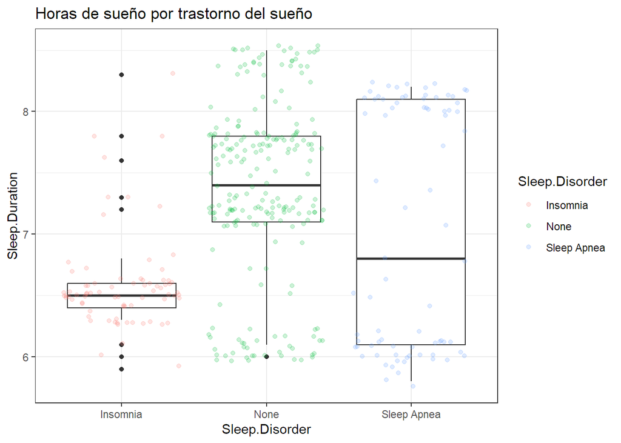

```r
datos2 |>
  ggplot(aes(x = Sleep.Disorder, y = Sleep.Duration)) +
  geom_boxplot() +
  geom_jitter(aes(col = Sleep.Disorder), alpha = 0.2) +
  theme_bw() +
  labs(title = "Horas de sueño por trastorno del sueño")
```

Se muestra la relación entre las horas de sueño y el tipo de trastorno. La mayoría de los participantes sin trastornos de sueño tienen una duración media de sueño dentro del rango normal (7-8 horas). En el caso de los participantes con insomnio, las horas de sueño son considerablemente más bajas, mientras que aquellos con apnea del sueño suelen tener una duración más dispersa

### 5.2.7 Calidad de sueño con estres

```r
calidad_de_sueño_estres <- datos2 |>
  mutate(rango_calidad = cut(Quality.of.Sleep, breaks = seq(floor(min(Quality.of.Sleep)), ceiling(max(Quality.of.Sleep)), by = 4), include.lowest = TRUE),
         rango_estres=cut(Stress.Level,breaks=3)) |>
  count(rango_calidad,
        rango_estres)

kable(calidad_de_sueño_estres)
```

| rango_calidad | rango_estres | n |
| --- | --- | --- |
| [4,8] | (3,4.67] | 70 |
| [4,8] | (4.67,6.33] | 113 |
| [4,8] | (6.33,8.01] | 120 |
| NA | (3,4.67] | 71 |

Covarianza

```r
cov(datos2$Quality.of.Sleep, datos2$Stress.Level)
```

```
## [1] -1.908976
```

Al resueltar una covarianza negativa presentan una relacion lineal negativa, creciendo una mientras la otra disminuye y viceversa.

Corelación

```r
cor(datos2$Quality.of.Sleep, datos2$Stress.Level)
```

```
## [1] -0.898752
```

Al ser valor proximo a -1 hay una relacion lineal fuerte entre ellas por lo que se modifican notablemente los datos. Gráfica de dispersión

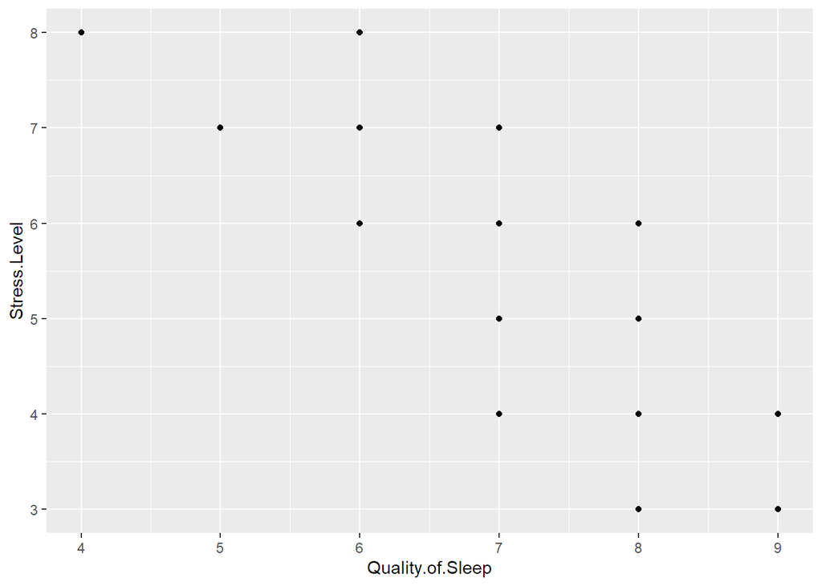

```r
datos2 |>
  ggplot(aes(x = Quality.of.Sleep, y = Stress.Level)) +
  geom_point()
```

El gráfico de dispersion muestra la calidad del sueño (eje x) frente al nivel de estrés de los participantes(eje Y). La dispersión muestra un aumento de la calidad del sueño conforme disminuye el nivel de estrés, centrándose los valores en una calidad de sueño de 7 y 8 y un nivel de estrés de 4 a 6.

Regresión lineal:

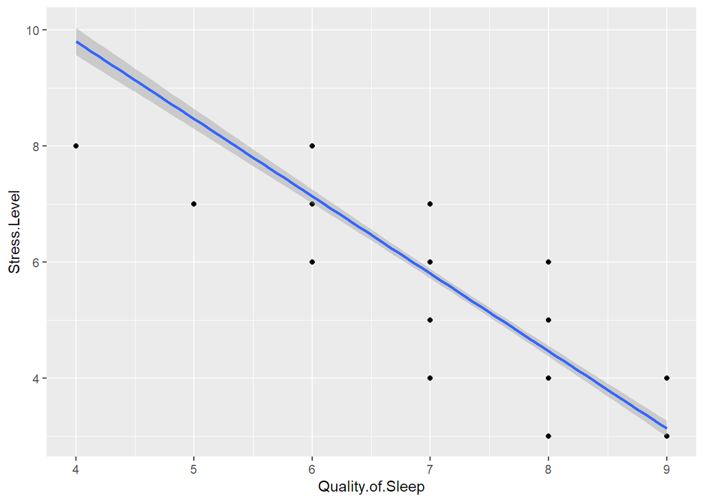

```r
datos2 |>
  ggplot(aes(x = Quality.of.Sleep, y = Stress.Level)) +
  geom_point() +
  geom_smooth(method = lm)
```

```r
calidad_de_sueño_estres <- lm(Quality.of.Sleep ~ Stress.Level, data = datos2)

summary(calidad_de_sueño_estres)
```

```
##
## Call:
## lm(formula = Quality.of.Sleep ~ Stress.Level, data = datos2)
##
## Residuals:
##     Min      1Q  Median      3Q     Max
## -1.7276 -0.1525  0.2413  0.2724  1.0600
##
## Coefficients:
##              Estimate Std. Error t value Pr(>|t|)
## (Intercept)  10.57739    0.08693  121.68   <2e-16 ***
## Stress.Level -0.60623    0.01533  -39.53   <2e-16 ***
## ---
## Signif. codes:  0 '***' 0.001 '**' 0.01 '*' 0.05 '.' 0.1 ' ' 1
##
## Residual standard error: 0.5255 on 372 degrees of freedom
## Multiple R-squared:  0.8078, Adjusted R-squared:  0.8072
## F-statistic:  1563 on 1 and 372 DF,  p-value: < 2.2e-16
```

### 5.2.8 Pasos diarios con BMI

Tabla comparativa

```r
table(datos2$Daily.Steps, datos2$BMI.Category)
```

```
##
##         Normal Normal Weight Obese Overweight
##   3000       0             0     3          0
##   3300       0             0     2          0
##   3500       0             0     3          0
##   3700       0             0     2          0
##   4000       0             2     0          1
##   4100       0             2     0          0
##   4200       0             0     0          2
##   4800       0             0     0          2
##   5000      63             0     0          5
##   5200       0             0     0          2
##   5500       0             1     0          3
##   5600       0             0     0          2
##   6000       0             1     0         67
##   6200       0             1     0          0
##   6800       0             2     0          1
##   7000      32             3     0         31
##   7300       0             2     0          0
##   7500       0             2     0          0
##   8000      98             3     0          0
##   10000      2             2     0         32
```

Gráfico de cajas:

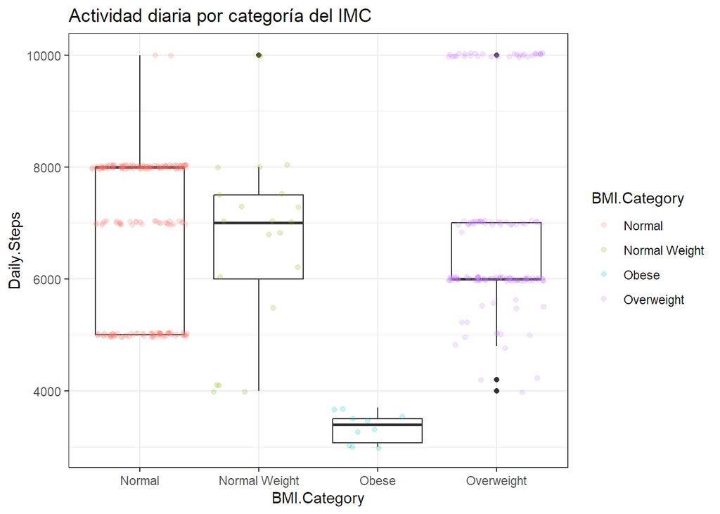

```r
datos2 |>
  ggplot(aes(x = BMI.Category, y = Daily.Steps)) +
  geom_boxplot() +
  geom_jitter(aes(col = BMI.Category), alpha = 0.2) +
  theme_bw() +
  labs(title = "Actividad diaria por categoría del IMC")
```

En el gráfico se muestra aquellos con un BMI dentro del rango normal o bajo peso que tienden a realizar más pasos diarios en comparación con las personas que están en la categoría de obesidad

### 5.2.9 Actividad Física con BMI

Tabla comparativa

```r
table(datos2$Physical.Activity.Level, datos2$BMI.Category)
```

```
##
##      Normal Normal Weight Obese Overweight
##   30     63             0     3          2
##   32      0             0     0          2
##   35      0             2     0          2
##   40      0             2     1          3
##   42      0             0     0          2
##   45      2             0     0         66
##   47      0             1     0          0
##   50      0             2     0          2
##   55      0             3     0          3
##   60     65             3     2          0
##   65      0             0     2          0
##   70      0             3     0          0
##   75     32             1     0         34
##   80      0             2     0          0
##   85      0             0     2          0
##   90     33             2     0         32
```

Gráfico de cajas:

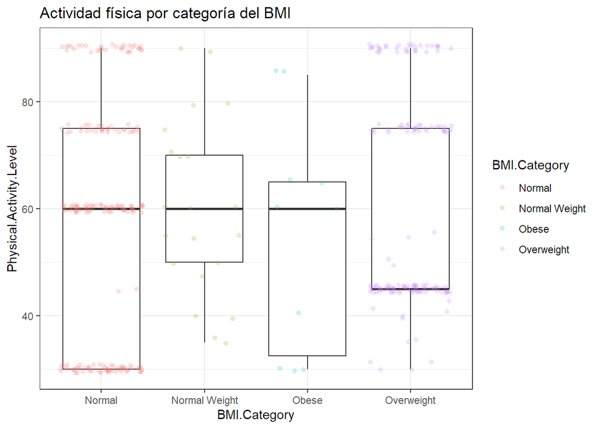

```r
datos2 |>
  ggplot(aes(x = BMI.Category, y = Physical.Activity.Level)) +
  geom_boxplot() +
  geom_jitter(aes(col = BMI.Category), alpha = 0.2) +
  theme_bw() +
  labs(title = "Actividad física por categoría del BMI")
```

### 5.2.10 Presion pulso BMI

Tabla comparativa

```r
table(datos2$Blood.Pressure, datos2$BMI.Category)
```

```
##
##          Normal Normal Weight Obese Overweight
##   115/75     32             0     0          0
##   115/78      0             2     0          0
##   117/76      0             2     0          0
##   118/75      0             2     0          0
##   118/76      0             1     0          0
##   119/77      0             2     0          0
##   120/80     40             5     0          0
##   121/79      0             1     0          0
##   122/80      0             0     0          1
##   125/80     65             0     0          0
##   125/82      0             1     0          3
##   126/83      0             0     0          2
##   128/84      0             0     0          2
##   128/85      0             1     0          2
##   129/84      0             0     0          2
##   130/85     58             0     0         41
##   130/86      0             2     0          0
##   131/86      0             0     0          2
##   132/87      0             2     0          1
##   135/88      0             0     2          0
##   135/90      0             0     0         27
##   139/91      0             0     2          0
##   140/90      0             0     4          0
##   140/95      0             0     0         65
##   142/92      0             0     2          0
```

Gráfico de barras

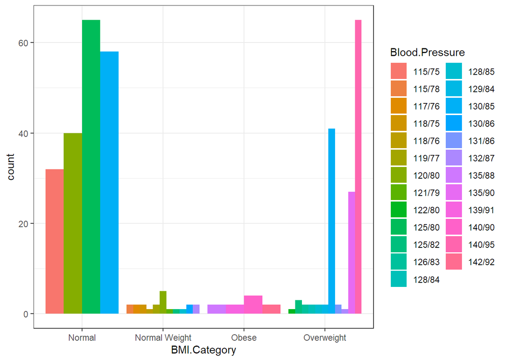

```r
datos2 |>
  ggplot(aes(x = BMI.Category, fill = Blood.Pressure)) +
  geom_bar(position = position_dodge()) +
  theme_bw()
```

### 5.2.11 Trastorno trabajo

Tabla comparativa

```r
table(datos2$Occupation, datos2$Sleep.Disorder)
```

```
##
##                        Insomnia None Sleep Apnea
##   Accountant                  7   30           0
##   Doctor                      3   64           4
##   Engineer                    5   57           1
##   Lawyer                      2   42           3
##   Manager                     0    1           0
##   Nurse                       3    9          61
##   Sales Representative        0    0           2
##   Salesperson                29    2           1
##   Scientist                   0    2           2
##   Software Engineer           1    3           0
##   Teacher                    27    9           4
```

Gráfico de barras

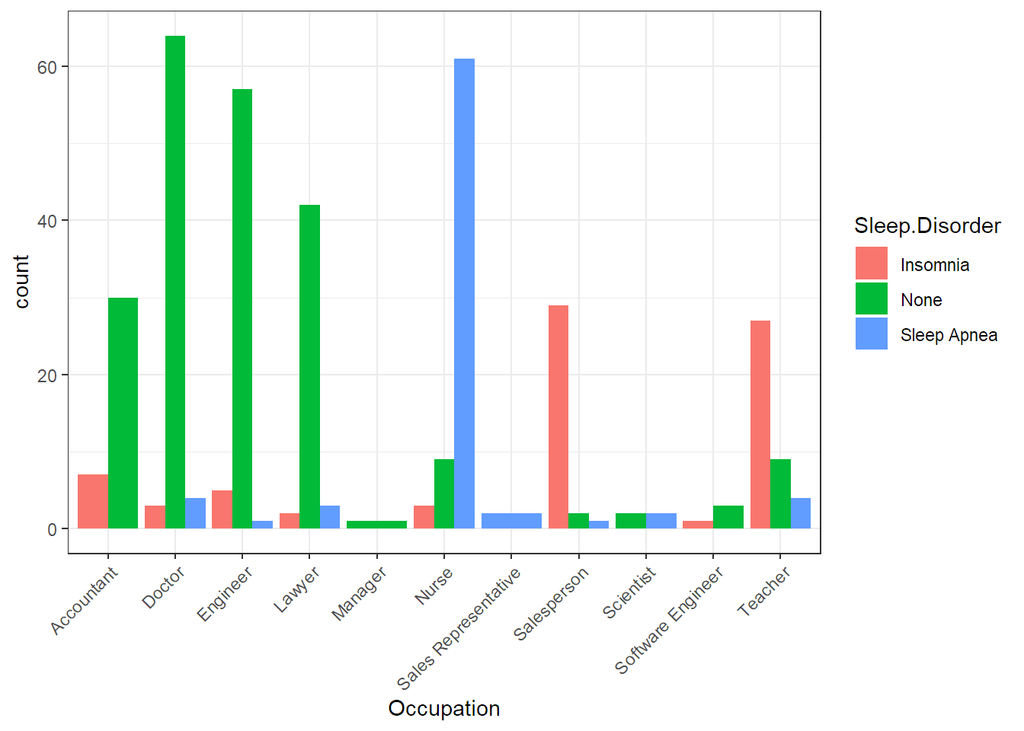

```r
datos2 |>
  ggplot(aes(x = Occupation, fill = Sleep.Disorder)) +
  geom_bar(position = position_dodge()) +
  theme_bw() +
  theme(axis.text.x = element_text(angle = 45, hjust = 1))
```

Gracias a esta tabla podemos apreciar los diferentes trastornos de sueño que suelen tener las distintas profesiones. De este modo, vemos que los contables, los doctores, los ingenieros y los abogados no suelen presentar ningún trastorno, los enfermeros suelen presentar apnea del sueño y los vendedores y profesores presentan en muchos casos insomnia.

# 6 Conclusiones